# ¿Cuánto cree la IA que vale tu casa?

Comencemos con un ejemplo típico dentro del mundo de la machine-learning (¡gracias, Andrew Ng!): predecir cuánto vale una casa en base a sus características ('features'). Las características son el conjunto de atributos de la casa sobre la que queremos predecir el precio: por ejemplo 'm²', 'n_plantas', 'n_habitaciones' , etc...

¿Has notado que solo he mencionado características numéricas? Esto es por que los modelos de ML 'entienden' mucho mejor los números, que los datos en otro formato. De hecho lo que mejor admiten son arrays de números normalizados (en el rango [0,1]). Quizás estás pensando que hay factores de naturaleza no numérica, que previsiblemente influirán en el precio de la casa que estamos prediciendo. Por ejemplo: la localización (¿En qué país está la casa?, ¿en qué barrio está?, ¿cuánto vale el metro cuadrado en esa zona?). El proceso para transformar estos datos en numéricos, se llama 'codificación' o 'encoding'.

Pero vamos a empezar por el principio: hemos elegido un dataset (conjunto de datos necesario para entrenar al modelo) de [Kaggle](https://www.kaggle.com/datasets/yasserh/housing-prices-dataset).

## Exploración de los datos

```python
import pandas as pd                      # librerías básicas para la manipulación de datos en ML
import numpy  as np                      # librerías básicas para la manipulación de datos en ML
```

```python
dataset = pd.read_csv('dataset.csv')     # lectura del dataset
```

```python
list(dataset.columns)                    # lista de 13 características
```

```
['price',
 'area',
 'bedrooms',
 'bathrooms',
 'stories',
 'mainroad',
 'guestroom',
 'basement',
 'hotwaterheating',
 'airconditioning',
 'parking',
 'prefarea',
 'furnishingstatus']
```

```python
dataset.shape                            # tamaño del dataset
```

```
(545, 13)
```

Tenemos un dataset de 545 registros, y 13 características para cada registro

```python
dataset
```

|  | price | area | bedrooms | bathrooms | stories | mainroad | guestroom | basement | hotwaterheating | airconditioning | parking | prefarea | furnishingstatus |
| --- | --- | --- | --- | --- | --- | --- | --- | --- | --- | --- | --- | --- | --- |
| 0 | 13300000 | 7420 | 4 | 2 | 3 | yes | no | no | no | yes | 2 | yes | furnished |
| 1 | 12250000 | 8960 | 4 | 4 | 4 | yes | no | no | no | yes | 3 | no | furnished |
| 2 | 12250000 | 9960 | 3 | 2 | 2 | yes | no | yes | no | no | 2 | yes | semi-furnished |
| 3 | 12215000 | 7500 | 4 | 2 | 2 | yes | no | yes | no | yes | 3 | yes | furnished |
| 4 | 11410000 | 7420 | 4 | 1 | 2 | yes | yes | yes | no | yes | 2 | no | furnished |
| ... | ... | ... | ... | ... | ... | ... | ... | ... | ... | ... | ... | ... | ... |
| 540 | 1820000 | 3000 | 2 | 1 | 1 | yes | no | yes | no | no | 2 | no | unfurnished |
| 541 | 1767150 | 2400 | 3 | 1 | 1 | no | no | no | no | no | 0 | no | semi-furnished |
| 542 | 1750000 | 3620 | 2 | 1 | 1 | yes | no | no | no | no | 0 | no | unfurnished |
| 543 | 1750000 | 2910 | 3 | 1 | 1 | no | no | no | no | no | 0 | no | furnished |
| 544 | 1750000 | 3850 | 3 | 1 | 2 | yes | no | no | no | no | 0 | no | unfurnished |

545 rows × 13 columns

¡Wow! Tenemos un montón de información. Comencemos con las columnas numéricas

```python
numeric_dataset = dataset.select_dtypes(include='number')
numeric_dataset
```

|  | price | area | bedrooms | bathrooms | stories | parking |
| --- | --- | --- | --- | --- | --- | --- |
| 0 | 13300000 | 7420 | 4 | 2 | 3 | 2 |
| 1 | 12250000 | 8960 | 4 | 4 | 4 | 3 |
| 2 | 12250000 | 9960 | 3 | 2 | 2 | 2 |
| 3 | 12215000 | 7500 | 4 | 2 | 2 | 3 |
| 4 | 11410000 | 7420 | 4 | 1 | 2 | 2 |
| ... | ... | ... | ... | ... | ... | ... |
| 540 | 1820000 | 3000 | 2 | 1 | 1 | 2 |
| 541 | 1767150 | 2400 | 3 | 1 | 1 | 0 |
| 542 | 1750000 | 3620 | 2 | 1 | 1 | 0 |
| 543 | 1750000 | 2910 | 3 | 1 | 1 | 0 |
| 544 | 1750000 | 3850 | 3 | 1 | 2 | 0 |

545 rows × 6 columns

Estaría bien poder hacer un resumen de los datos...

```python
numeric_dataset.describe()
```

|  | price | area | bedrooms | bathrooms | stories | parking |
| --- | --- | --- | --- | --- | --- | --- |
| count | 5.450000e+02 | 545.000000 | 545.000000 | 545.000000 | 545.000000 | 545.000000 |
| mean | 4.766729e+06 | 5150.541284 | 2.965138 | 1.286239 | 1.805505 | 0.693578 |
| std | 1.870440e+06 | 2170.141023 | 0.738064 | 0.502470 | 0.867492 | 0.861586 |
| min | 1.750000e+06 | 1650.000000 | 1.000000 | 1.000000 | 1.000000 | 0.000000 |
| 25% | 3.430000e+06 | 3600.000000 | 2.000000 | 1.000000 | 1.000000 | 0.000000 |
| 50% | 4.340000e+06 | 4600.000000 | 3.000000 | 1.000000 | 2.000000 | 0.000000 |
| 75% | 5.740000e+06 | 6360.000000 | 3.000000 | 2.000000 | 2.000000 | 1.000000 |
| max | 1.330000e+07 | 16200.000000 | 6.000000 | 4.000000 | 4.000000 | 3.000000 |

¿Hay algún valor nulo que nos vaya a jo**r el entrenamiento?

```python
numeric_dataset.info()
```

```
<class 'pandas.core.frame.DataFrame'>
RangeIndex: 545 entries, 0 to 544
Data columns (total 6 columns):
 #   Column     Non-Null Count  Dtype
---  ------     --------------  -----
 0   price      545 non-null    int64
 1   area       545 non-null    int64
 2   bedrooms   545 non-null    int64
 3   bathrooms  545 non-null    int64
 4   stories    545 non-null    int64
 5   parking    545 non-null    int64
dtypes: int64(6)
memory usage: 25.7 KB
```

## Preparación de los datos - Preprocesamiento

Ya conocemos la estructura de nuestros datos, ahora toca currarselo y prepararlos para el modelo. Esta parte es muy importante, aunque consigamos encontrar la arquitectura perfecta para la tarea a resolver, si los datos de entrenamiento no están bien, el modelo no va a aprender.

#### Data Cleaning y Data Integration

Al descargar datasets de Kaggle, nos podemos ahorrar esta parte muchas veces, pero este proceso involucraría revisar los resumenes del df con .describe o .info, o incluso manualmente con scripts, para encontrar discrepancias en los datos.

#### Data Transformation

Debemos normalizar y estandarizar nuestros datos. Para ello es especialmente útil la librería sklearn: **MinMaxScaler** normaliza,se encarga de que los valores de las características estén en el rango [0,1]; y **StandardScaler** se encarga normalizar, es decir ajustar los valores de las características para que tengan una media de 0 y una desviación estándar de 1

```python
from sklearn.preprocessing import MinMaxScaler, StandardScaler

normalizer  = MinMaxScaler()
standarizer = StandardScaler()
normal_     = normalizer.fit_transform(numeric_dataset)
standard_   = standarizer.fit_transform(normal_)
dataset     = pd.DataFrame(standard_, columns=numeric_dataset.columns)
dataset.reset_index(drop=True)
dataset
```

|  | price | area | bedrooms | bathrooms | stories | parking |
| --- | --- | --- | --- | --- | --- | --- |
| 0 | 4.566365 | 1.046726 | 1.403419 | 1.421812 | 1.378217 | 1.517692 |
| 1 | 4.004484 | 1.757010 | 1.403419 | 5.405809 | 2.532024 | 2.679409 |
| 2 | 4.004484 | 2.218232 | 0.047278 | 1.421812 | 0.224410 | 1.517692 |
| 3 | 3.985755 | 1.083624 | 1.403419 | 1.421812 | 0.224410 | 2.679409 |
| 4 | 3.554979 | 1.046726 | 1.403419 | -0.570187 | 0.224410 | 1.517692 |
| ... | ... | ... | ... | ... | ... | ... |
| 540 | -1.576868 | -0.991879 | -1.308863 | -0.570187 | -0.929397 | 1.517692 |
| 541 | -1.605149 | -1.268613 | 0.047278 | -0.570187 | -0.929397 | -0.805741 |
| 542 | -1.614327 | -0.705921 | -1.308863 | -0.570187 | -0.929397 | -0.805741 |
| 543 | -1.614327 | -1.033389 | 0.047278 | -0.570187 | -0.929397 | -0.805741 |
| 544 | -1.614327 | -0.599839 | 0.047278 | -0.570187 | 0.224410 | -0.805741 |

545 rows × 6 columns

#### Detectar Outliers

Queremos detectar valores atípicos. Valores que no encajen ni con cola, que sean incoherentes con el resto, o muy raros. Para casos sencillos (y no tan sencillos), visualizar los datos es la primera opción. Para ello te recomiendo familiarizarte con matplotlib y seaborn

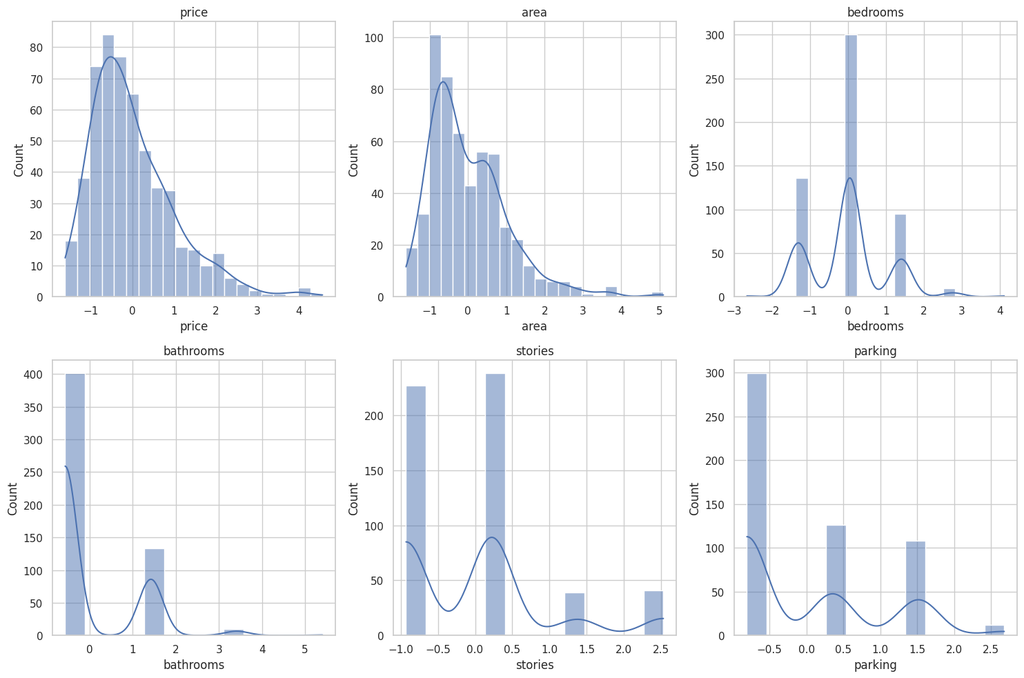

```python
import pandas as pd
import matplotlib.pyplot as plt
import seaborn as sns


sns.set(style="whitegrid")                                   # Configurar el estilo de los gráficos


fig, axs = plt.subplots(2, 3, figsize=(15, 10))              # Crear subplots


num_cols = min(len(dataset.columns), 6)
for i, col in enumerate(dataset.columns[:num_cols]):             # Recorremos columnas
    sns.histplot(dataset[col], ax=axs[i//3, i%3], kde=True)      # Crear histogramas para cada columna
    axs[i//3, i%3].set_title(col)


plt.tight_layout()                                           # Ajustar diseño
plt.show()                                                   # Plotear
```

Más allá del precio desorbitado de algún chalet de la Moraleja, no parece haber datos atípicos.

#### Separar los conjuntos

Debemos dividir el dataset en 3: entrenamiento, test, y validación. Nuevamente la solución más estándar es recurrir a sklearn. Seteamos un random_state, por que de no hacerlo, si volvemos a ejecutar el codigo separa los registros de forma distinta.

```python
from sklearn.model_selection import train_test_split

temporal_df, test_df = train_test_split(dataset, test_size=0.3, random_state=42)        # Dividir el conjunto en entrenamiento (70%) y temporal (30%)
train_df, val_df = train_test_split(temporal_df, test_size=0.33, random_state=42)       # Dividir el conjunto temporal en prueba (20%) y validación (10%)
```

```python
train_df
```

|  | price | area | bedrooms | bathrooms | stories | parking |
| --- | --- | --- | --- | --- | --- | --- |
| 156 | 0.404699 | 0.806890 | 0.047278 | -0.570187 | -0.929397 | -0.805741 |
| 150 | 0.445904 | -0.006707 | 0.047278 | -0.570187 | 0.224410 | -0.805741 |
| 317 | -0.378188 | -0.073123 | 0.047278 | 1.421812 | 0.224410 | 1.517692 |
| 282 | -0.265812 | -1.372388 | 0.047278 | -0.570187 | 0.224410 | -0.805741 |
| 122 | 0.633198 | 0.508940 | 1.403419 | 1.421812 | -0.929397 | 0.355976 |
| ... | ... | ... | ... | ... | ... | ... |
| 141 | 0.473998 | 0.696197 | 1.403419 | 1.421812 | 0.224410 | 0.355976 |
| 334 | -0.453106 | -0.858124 | -1.308863 | -0.570187 | -0.929397 | 0.355976 |
| 128 | 0.591993 | 0.161178 | 0.047278 | -0.570187 | 1.378217 | 0.355976 |
| 243 | -0.115977 | -1.199429 | 0.047278 | -0.570187 | 0.224410 | -0.805741 |
| 403 | -0.677858 | 3.594521 | 0.047278 | -0.570187 | -0.929397 | -0.805741 |

255 rows × 6 columns

#### Separar Características y objetivo

¿Qué queremos predecir? El precio

¿Qué tenemos para predecirlo? El resto de columnas. Comencemos comparando precio vs área:

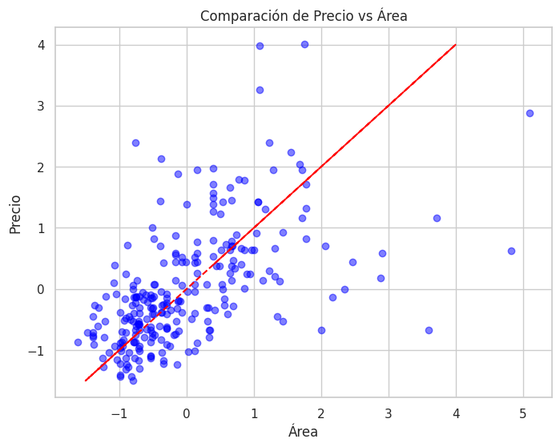

```python
# Crear el gráfico de dispersión
plt.figure(figsize=(8, 6))
plt.scatter(train_df['area'], train_df['price'], color='blue', alpha=0.5)
plt.plot(train_df['price'], train_df['price'], color='red', linestyle='--', label='x = y')
plt.title('Comparación de Precio vs Área')
plt.xlabel('Área')
plt.ylabel('Precio')
plt.grid(True)
plt.show()
```

#### Enfoque Naive

Como podemos ver hay una correlación lineal entre el área y el precio de una casa, un enfoque básico sería intentar hallar la línea recta que minimiza la suma de las distancias cuadráticas (errores cuadráticos) de todos los registros. Queremos encontrar los parámetros óptimos de la ecuación de una recta $y = bx + a + \epsilon $ o, en términos de parámetros, $$y = \theta_1 \cdot x + \theta_0 + \epsilon$$

Vectorialmente, esta relación lineal se puede representar como $y = \mathbf{\theta}^T \cdot [x, 1]$, donde $\mathbf{\theta} = [\theta_1, \theta_0]^T$ es el vector de parámetros y $[x, 1]$ representa el vector de características ampliado con un término constante para incorporar $\theta_0$

```python
# ¿Cómo podemos resolver el sistema?
# https://es.wikipedia.org/wiki/M%C3%ADnimos_cuadrados_ordinarios#Modelo_de_regresi%C3%B3n_simple

X_mean = np.mean(train_df['area'])                                              # características con las que predecimos
Y_mean = np.mean(train_df['price'])                                             # característica a predecir
beta_1 = np.sum((train_df['area'] - X_mean) * (train_df['price'] - Y_mean)) / np.sum((train_df['area'] - X_mean) ** 2)  # pendiente
beta_0 = Y_mean - beta_1 * X_mean                                                                                       # valor cuando x=0
```

```python
beta_1
```

```
0.5223781530463021
```

```python
beta_0
```

```
0.012812037093126862
```

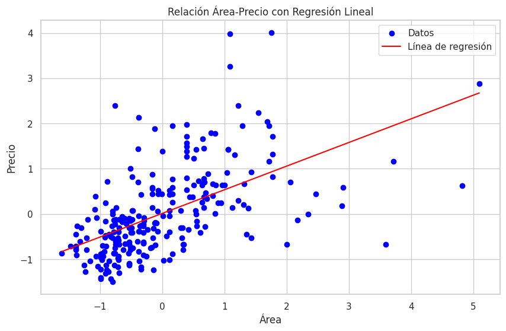

```python
# Función para la línea de regresión
def regression_line(x):
    return beta_0 + beta_1 * x

# Valores para la línea de regresión
x_values = np.linspace(train_df['area'].min(), train_df['area'].max(), 100)  # 100 puntos entre el min y max de 'area'
y_values = regression_line(x_values)

# Creando la gráfica
plt.figure(figsize=(10, 6))
plt.scatter(train_df['area'], train_df['price'], color='blue', label='Datos')  # Datos reales
plt.plot(x_values, y_values, color='red', label='Línea de regresión')  # Línea de regresión
plt.title('Relación Área-Precio con Regresión Lineal')
plt.xlabel('Área')
plt.ylabel('Precio')
plt.legend()
plt.show()
```

```python
# Calcular el error cuadrático medio
predictions = beta_0 + beta_1 * train_df['area']
mse_train = np.mean((train_df['price'] - predictions) ** 2)
mse_train
```

```
0.6329814195288301
```

Parece que funciona, pero esto es sólo con los datos de entrenamiento. ¿Qué tal geralizará a en los otros conjuntos? Por otro lado, ya que los hemos calculado, para algo habrá que usarlos

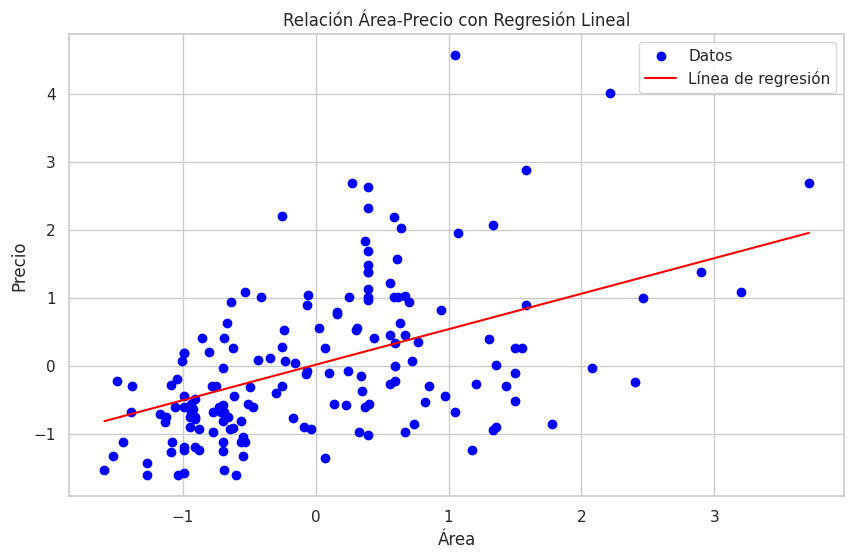

```python
# Función para la línea de regresión
def regression_line(x):
    return beta_0 + beta_1 * x

# Valores para la línea de regresión
x_values = np.linspace(test_df['area'].min(), test_df['area'].max(), 100)  # 100 puntos entre el min y max de 'area'
y_values = regression_line(x_values)

# Creando la gráfica
plt.figure(figsize=(10, 6))
plt.scatter(test_df['area'], test_df['price'], color='blue', label='Datos')  # Datos reales
plt.plot(x_values, y_values, color='red', label='Línea de regresión')  # Línea de regresión
plt.title('Relación Área-Precio con Regresión Lineal')
plt.xlabel('Área')
plt.ylabel('Precio')
plt.legend()
plt.show()
```

```python
# Calcular el error cuadrático medio
predictions = beta_0 + beta_1 * test_df['area']
mse_test = np.mean((test_df['price'] - predictions) ** 2)
mse_test
```

```
0.9148314278504351
```

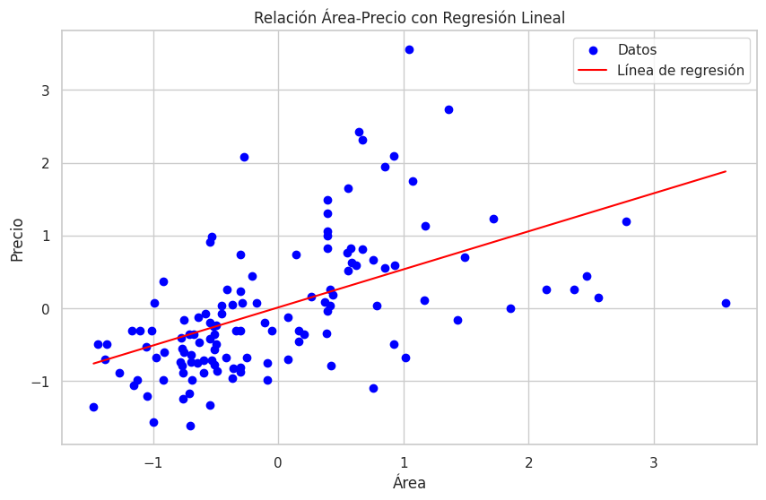

```python
# Función para la línea de regresión
def regression_line(x):
    return beta_0 + beta_1 * x

# Valores para la línea de regresión
x_values = np.linspace(val_df['area'].min(), val_df['area'].max(), 100)  # 100 puntos entre el min y max de 'area'
y_values = regression_line(x_values)

# Creando la gráfica
plt.figure(figsize=(10, 6))
plt.scatter(val_df['area'], val_df['price'], color='blue', label='Datos')  # Datos reales
plt.plot(x_values, y_values, color='red', label='Línea de regresión')  # Línea de regresión
plt.title('Relación Área-Precio con Regresión Lineal')
plt.xlabel('Área')
plt.ylabel('Precio')
plt.legend()
plt.show()
```

```python
# Calcular el error cuadrático medio
predictions = beta_0 + beta_1 * val_df['area']
mse_test = np.mean((val_df['price'] - predictions) ** 2)
mse_test
```

```
0.6124854229028082
```

Es un enfoque simplista, pero permite estimar si una vivienda esta infravalorada o sobrevalorada, en base a su precio y su área

# Ahora, ¿Cómo funciona realmente el ML?

El primer paso es seleccionar una arquitectura de modelo adecuada que pueda abordar el problema en cuestión, que no es tarea sencilla. Una vez establecida esta arquitectura, procedemos a entrenar el modelo utilizando el conjunto de datos de entrenamiento.

El proceso de entrenamiento se caracteriza por una reducción iterativa de una métrica conocida como 'valor de pérdida'. El modelo recibe un conjunto de entradas que representan las características de un registro concreto. Estas entradas se procesan secuencialmente a través de las capas del modelo, acabando en una predicción. A continuación, la predicción se compara con el valor real, y esta comparación da lugar a una estimación de la pérdida, que mide cuán lejos estuvo la predicción del valor real.

Basándose en esta pérdida, el modelo ajusta internamente los pesos de sus capas, con el objetivo de mejorar las predicciones en futuras iteraciones. Lo vemos en más profundidad en el próximo tutorial, ¡espero que os haya gustado y hayáis aprendido algo nuevo!

##### Recursos

[Andrew Ng](https://www.coursera.org/specializations/machine-learning-introduction)

[GPT3.5](https://chat.openai.com)